# Enron Person-of-Interest Identifier Project

### Josh Lovelace 09/01/2016

Welcome to my machine learning project, created as a final project for Udacity's machine learning course. In this project, the wealth of information available from Enron's fraud case is utilized to create a person-of-interest identifier algorithm.

This document exists to explain the thought processes behind the creation of the identifier as well as to detail the hazards that were overcome. At the end of this document will be a set of free-response questions and answers.

```python
%matplotlib inline
import sys
import pickle
import numpy as np
import matplotlib.pyplot as plt

sys.path.append("C:/Users/Bash/Desktop/Udacity/2_Data_Analysis/P5-ML/ud120-projects/tools/")
from feature_format import featureFormat, targetFeatureSplit
from tester import dump_classifier_and_data,load_classifier_and_data,test_classifier
from sklearn.naive_bayes import GaussianNB
from sklearn.tree import DecisionTreeClassifier
from sklearn.ensemble import GradientBoostingClassifier, AdaBoostClassifier, RandomForestClassifier, VotingClassifier
from sklearn.feature_selection import SelectKBest, f_classif, RFECV, SelectFdr
from sklearn.cross_validation import StratifiedKFold, StratifiedShuffleSplit
from sklearn.metrics import f1_score
```

## Project Plan

The project will follow these steps:

1. Feature Selection
2. Outlier Removal
3. Classifier Testing
4. Classifier Tuning

### The Data

The Enron corpus of emails and financial data has been a testing grounds for scientists for decades. It is detailed, rigorous, politically and economically relevant - it has been sifted many ways and by many different scientific disciplines. However, there are a number of characteristics of our data that leave much to be desired for the creation of a POI identification algorithm. In brief, the dataset used within contains 145 observations of 19 features as well as the 'poi' binary label. Many values are NaN's, and POI's represent only 18 of our 145 observations. With so few POI's to train our algorithm for identification, and much training variation lost to NaN's, our expectations for the performance of the algorithm ought to be somewhat modest. For the sake of providing a safe target, Udacity rubrics provide a target precision and recall of 0.3. I hope to exceed that number by as much as I can manage.

### Feature Selection

For feature selection, I use a recursive feature elimination method, eventually settling on six features that adequately separate POI's from non-POI's. As you will see, however, we will not arrive at our best features until after outlier removal.

As this is a recursive method, we start with our full set of features.

```
Optimal number of features - Recall : 3
Optimal number of features - Precision : 5
Best features: ['from_poi_to_this_person', 'shared_receipt_with_poi']
from_poi_to_this_person Score: 5.44668748333 P-value: 0.0209984606978
shared_receipt_with_poi Score: 8.90382155717 P-value: 0.00334758801368
```

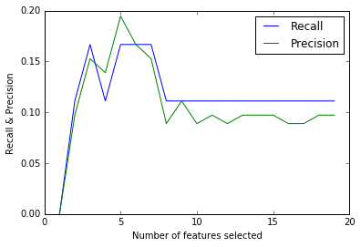

```python
features_list = ['poi','salary', 'deferral_payments', 'total_payments', 'loan_advances',
                 'bonus', 'restricted_stock_deferred', 'deferred_income',
                 'total_stock_value', 'expenses', 'exercised_stock_options',
                 'other', 'long_term_incentive', 'restricted_stock',
                 'director_fees','to_messages',
                 'from_poi_to_this_person', 'from_messages',
                 'from_this_person_to_poi', 'shared_receipt_with_poi']


with open("final_project_dataset.pkl", "r") as data_file:
    data_dict = pickle.load(data_file)

my_dataset = data_dict
data = featureFormat(my_dataset, features_list, sort_keys = True)
labels, features = targetFeatureSplit(data)

## Recursive feature elimination
def feature_select(labels,features,alfa=0.4):
    dct = DecisionTreeClassifier(random_state=42)
    rfecv1 = RFECV(estimator=dct, step=1, cv=StratifiedKFold(labels, n_folds=6,shuffle=True,random_state=42),
                  scoring='recall')
    rfecv2 = RFECV(estimator=dct, step=1, cv=StratifiedKFold(labels, n_folds=6,shuffle=True,random_state=42),
              scoring='precision')
    rfecv1.fit(features,labels)
    rfecv2.fit(features,labels)
    print("Optimal number of features - Recall : %d" % rfecv1.n_features_)
    print("Optimal number of features - Precision : %d" % rfecv2.n_features_)

    BestFeatures = SelectFdr(score_func=f_classif,alpha=alfa)
    BestFeatures.fit_transform(features,labels)
    feature_scores = BestFeatures.scores_
    feature_pvalues = BestFeatures.pvalues_
    best_feat_indices = BestFeatures.get_support(indices=True)

    best_list = []
    for i in range(len(best_feat_indices)):
        best_list.append(features_list[best_feat_indices[i]+1])

    print 'Best features:', best_list
    feat_ctr=-1
    for index in best_feat_indices:
        feat_ctr+=1
        print best_list[feat_ctr],'Score:',feature_scores[index],'P-value:',feature_pvalues[index]

    plt.figure()
    plt.xlabel("Number of features selected")
    plt.ylabel("Recall & Precision")
    plt.plot(range(1, len(rfecv1.grid_scores_) + 1), rfecv1.grid_scores_,
             label='Recall',color='blue')
    plt.plot(range(1, len(rfecv2.grid_scores_) + 1), rfecv2.grid_scores_,
             label='Precision',color='green')
    plt.legend()
    plt.show()

feature_select(labels,features)
```

### Feature Analysis

Because the dataset has very few POI's, general accuracy does not provide the best measure for a feature's power in identifying POI's - if a feature identified every point as non-POI, for instance, it would still attain an accuracy score of nearly 88%. As such, we will use Recall and Precision as our means of judging the efficacy of our features.

For the same reason, I chose to use the SelectFdr method within the feature_select function. SelectFdr allows the user to adjust selection based on the feature's false discovery rate rather than its accuracy. False discovery rate is tied directly to precision and recall rather than the identification of 'true negatives' alone, making it a better method than SelectKBest or SelectPercentile, which primarily use accuracy to rate features.

It's plain to see that our selected 'best features' have very poor p-values and low accuracy scores even with an alpha of 0.4. Rather than depend on our recursive feature selection now, I chose to hand-pick three variables that, based on knowledge of the Enron case, would seem to correlate well with POI identification. Using these features, I can analyze any issues with our data.

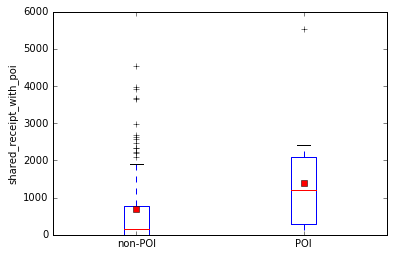

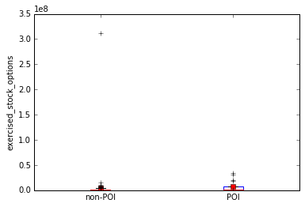

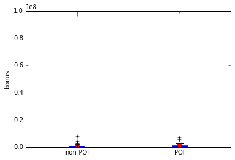

```python
features_list = ['poi','shared_receipt_with_poi','exercised_stock_options','bonus']

with open("final_project_dataset.pkl", "r") as data_file:
    data_dict = pickle.load(data_file)
my_dataset = data_dict

data = featureFormat(my_dataset, features_list, sort_keys = True)
labels, features = targetFeatureSplit(data)

def analyze_feature(feature_list,feature_num,labels,features):
    poi_feature_ob =[]
    npoi_feature_ob =[]

    for i in range(len(labels)):
        if labels[i] == 0:
            npoi_feature_ob.append(features[i][feature_num])
        if labels[i] == 1:
            poi_feature_ob.append(features[i][feature_num])

    poi_vs_npoi = [npoi_feature_ob,poi_feature_ob]
    plot_labels = ['non-POI','POI']

    plt.figure()
    plt.boxplot(poi_vs_npoi,showmeans=True)
    plt.ylabel(feature_list[feature_num])
    plt.xticks([1,2],plot_labels)
    plt.show()

def analyze_features(feature_list,labels,features):
    relevant_features = feature_list[1:]

    for feat in range(len(relevant_features)):
        analyze_feature(relevant_features,feat,labels,features)

analyze_features(features_list,labels,features)
```

As suspected, there is a big problem with outliers within our data - there is a 'TOTAL' entry within our data dictionary for all financial information. This helps explain why all of the previously selected features were weak as well as email-related. Let's eliminate the 'TOTAL' entry and start over.

### Outlier Removal

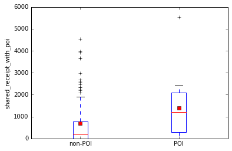

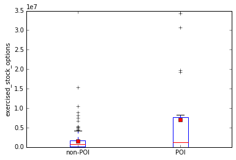

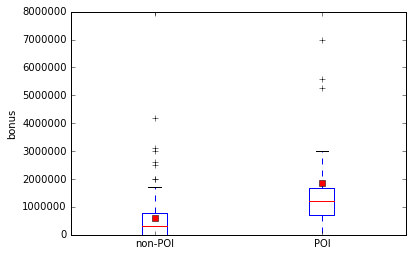

```python
del my_dataset['TOTAL']

features_list = ['poi','shared_receipt_with_poi','exercised_stock_options','bonus']
data = featureFormat(my_dataset, features_list, sort_keys = True)
labels, features = targetFeatureSplit(data)

analyze_features(features_list,labels,features)
```

This appears to be a much healthier dataset. The differences between non-POI's and POI's are apparent, and there are some outliers, but the outliers are within our expectations.

Let's retry our feature elimation recursion.

```
Optimal number of features - Recall : 3
Optimal number of features - Precision : 6
Best features: ['salary', 'total_payments', 'bonus', 'deferred_income', 'total_stock_value', 'exercised_stock_options', 'long_term_incentive', 'restricted_stock', 'shared_receipt_with_poi']
salary Score: 18.575703268 P-value: 3.03379610753e-05
total_payments Score: 8.86672153711 P-value: 0.00341592137059
bonus Score: 21.0600017075 P-value: 9.70247434123e-06
deferred_income Score: 11.5955476597 P-value: 0.00085980314392
total_stock_value Score: 24.4676540475 P-value: 2.10580664901e-06
exercised_stock_options Score: 25.0975415287 P-value: 1.59454384636e-06
long_term_incentive Score: 10.0724545294 P-value: 0.00184543514661
restricted_stock Score: 9.34670079105 P-value: 0.00266996113932
shared_receipt_with_poi Score: 8.74648553213 P-value: 0.00363440202436
```

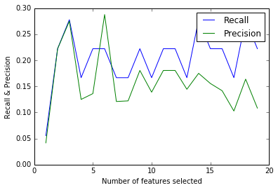

```python
features_list = ['poi','salary', 'deferral_payments', 'total_payments', 'loan_advances',
                 'bonus', 'restricted_stock_deferred', 'deferred_income',
                 'total_stock_value', 'expenses', 'exercised_stock_options',
                 'other', 'long_term_incentive', 'restricted_stock',
                 'director_fees','to_messages',
                 'from_poi_to_this_person', 'from_messages',
                 'from_this_person_to_poi', 'shared_receipt_with_poi']
data = featureFormat(my_dataset, features_list, sort_keys = True)
labels, features = targetFeatureSplit(data)

feature_select(labels,features,alfa=0.01)
```

While still somewhat chaotic, our recursion behaved much better this time around, with both Recall and Precision nearly reaching 0.3. SelectFdr can expose nine different features that are effective at alpha=0.01, and our RFECV graph shows that either 3 or 6 features ought to give us the best performance.

With this in mind, I combined the POI-related email features into a single feature.

```
Optimal number of features - Recall : 7
Optimal number of features - Precision : 2
Best features: ['salary', 'total_payments', 'bonus', 'deferred_income', 'total_stock_value', 'exercised_stock_options', 'long_term_incentive', 'restricted_stock', 'poi_email_contact']
salary Score: 18.575703268 P-value: 3.03379610753e-05
total_payments Score: 8.86672153711 P-value: 0.00341592137059
bonus Score: 21.0600017075 P-value: 9.70247434123e-06
deferred_income Score: 11.5955476597 P-value: 0.00085980314392
total_stock_value Score: 24.4676540475 P-value: 2.10580664901e-06
exercised_stock_options Score: 25.0975415287 P-value: 1.59454384636e-06
long_term_incentive Score: 10.0724545294 P-value: 0.00184543514661
restricted_stock Score: 9.34670079105 P-value: 0.00266996113932
poi_email_contact Score: 8.77384703851 P-value: 0.00358345047211
```

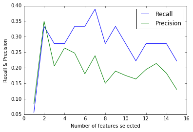

```python
for entry in my_dataset:
    poi_track = 0
    if my_dataset[entry]['from_poi_to_this_person'] != 'NaN':
        poi_track = my_dataset[entry]['from_poi_to_this_person']
    if my_dataset[entry]['from_this_person_to_poi'] != 'NaN':
        poi_track += my_dataset[entry]['from_this_person_to_poi']
    if my_dataset[entry]['shared_receipt_with_poi'] != 'NaN':
        poi_track += my_dataset[entry]['shared_receipt_with_poi']
    my_dataset[entry]['poi_email_contact'] = poi_track


features_list = ['poi','salary', 'deferral_payments', 'total_payments', 'loan_advances',
                 'bonus', 'restricted_stock_deferred', 'deferred_income',
                 'total_stock_value', 'expenses', 'exercised_stock_options',
                 'other', 'long_term_incentive', 'restricted_stock',
                 'director_fees','poi_email_contact']

data = featureFormat(my_dataset, features_list, sort_keys = True)
labels, features = targetFeatureSplit(data)

feature_select(labels,features,alfa=0.01)
```

Although the new 'poi_email_contact' feature was only barely more accurate than 'shared_receipt_with_poi', it did have a somewhat dramatic effect on the recall overall to remove the other email-related variables. We ought to keep in mind, though, that due to the very small number of POI's, a single miscategorization of a POI can cause the recall to appear to swing very wildly. We need to conduct a manifold cross-validation on our best features.

Before we start our cross-validation, let's take a look at our best features to make sure they look ready for testing.

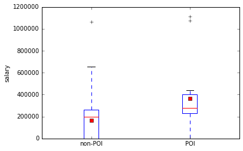

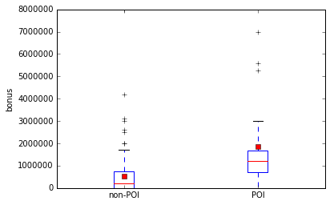

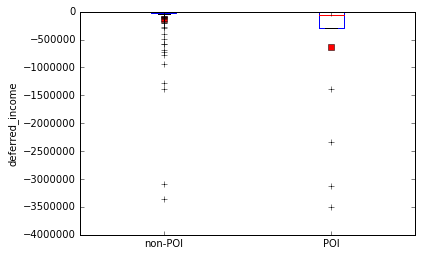

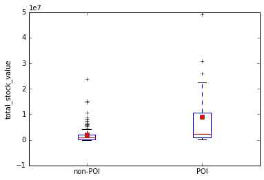

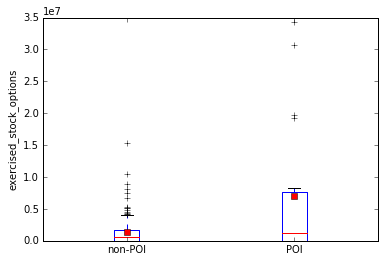

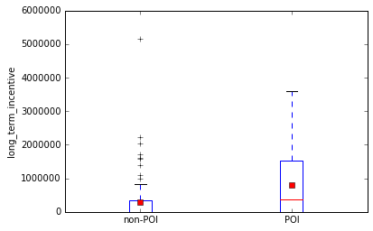

```python
features_list = ['poi','salary','bonus','deferred_income','total_stock_value',
                'exercised_stock_options','long_term_incentive']
data = featureFormat(my_dataset, features_list, sort_keys = True)
labels, features = targetFeatureSplit(data)

def analyze_feature(feature_list,feature_num,labels,features):
    poi_feature_ob =[]
    npoi_feature_ob =[]

    for i in range(len(labels)):
        if labels[i] == 0:
            npoi_feature_ob.append(features[i][feature_num])
        if labels[i] == 1:
            poi_feature_ob.append(features[i][feature_num])

    poi_vs_npoi = [npoi_feature_ob,poi_feature_ob]
    plot_labels = ['non-POI','POI']

    plt.figure()
    plt.boxplot(poi_vs_npoi,showmeans=True)
    plt.ylabel(feature_list[feature_num])
    plt.xticks([1,2],plot_labels)
    plt.show()

def analyze_features(feature_list,labels,features):
    relevant_features = feature_list[1:]

    for feat in range(len(relevant_features)):
        analyze_feature(relevant_features,feat,labels,features)

analyze_features(features_list,labels,features)
```

These features look very promising. The means, represented by the red squares, are very different between POI and non-POI boxplots, and the quartiles themselves are significantly different between the two.

### Classifier Testing

Now that we have strong features to use in identifying our POIs, we will create and fit some classifiers. I fit different classifiers as well as a 'soft' voting classifier, which takes the probabilities of the previous four fits and uses them to make a combined prediction.

As StratifiedShuffleSplit() is used in the grading program, I have used that same method for cross-validation. Stratified CVs are especially useful in the case where targets are relatively rare, as our POIs are. A tally is created for the best classifier (identified by F1 score) of true/false positives/negatives in order to produce precision and recall scores.

```python
PERF_FORMAT_STRING = "\
\tAccuracy: {:>0.{display_precision}f}\tPrecision: {:>0.{display_precision}f}\t\
Recall: {:>0.{display_precision}f}\tF1: {:>0.{display_precision}f}\tF2: {:>0.{display_precision}f}"
RESULTS_FORMAT_STRING = "\tTotal predictions: {:4d}\tTrue positives: {:4d}\tFalse positives: {:4d}\
\tFalse negatives: {:4d}\tTrue negatives: {:4d}"

clf = GaussianNB()
clf2 = GradientBoostingClassifier(random_state=42)
clf3 = AdaBoostClassifier(random_state=42)
clf4 = RandomForestClassifier(random_state=42)
clf_list = [('gnb',clf),('grdbst',clf2),('adabst',clf3),('rdmfst',clf4)]

clfvote = VotingClassifier(estimators=clf_list,voting='soft')

cv = StratifiedShuffleSplit(labels, 1000, random_state = 24)
true_negatives = 0
false_negatives = 0
true_positives = 0
false_positives = 0
clf_f1 = []
clf2_f1 = []
clf3_f1 = []
clf4_f1 = []
clfvote_f1 = []

for train_idx, test_idx in cv:
    features_train = []
    features_test  = []
    labels_train   = []
    labels_test    = []
    for ii in train_idx:
        features_train.append( features[ii] )
        labels_train.append( labels[ii] )
    for jj in test_idx:
        features_test.append( features[jj] )
        labels_test.append( labels[jj] )


    clf.fit(features_train, labels_train)
    clf2.fit(features_train, labels_train)
    clf3.fit(features_train, labels_train)
    clf4.fit(features_train, labels_train)
    clfvote.fit(features_train, labels_train)

    predictions1 = clf.predict(features_test)
    predictions2 = clf2.predict(features_test)
    predictions3 = clf3.predict(features_test)
    predictions4 = clf4.predict(features_test)
    predictions = clfvote.predict(features_test)

    clf_f1.append(f1_score(labels_test,predictions1))
    clf2_f1.append(f1_score(labels_test,predictions2))
    clf3_f1.append(f1_score(labels_test,predictions3))
    clf4_f1.append(f1_score(labels_test,predictions4))
    clfvote_f1.append(f1_score(labels_test,predictions))

    # Added after GaussianNB() known to be best clf to evaluate
    for prediction, truth in zip(predictions1, labels_test):
        if prediction == 0 and truth == 0:
            true_negatives += 1
        elif prediction == 0 and truth == 1:
            false_negatives += 1
        elif prediction == 1 and truth == 0:
            false_positives += 1
        elif prediction == 1 and truth == 1:
            true_positives += 1
        else:
            print "Warning: Found a predicted label not == 0 or 1."
            print "All predictions should take value 0 or 1."
            print "Evaluating performance for processed predictions:"
            break

print 'Gaussian Naive Bayes Avg F1:', np.mean(clf_f1)
print 'Gradient Boost Avg F1:', np.mean(clf2_f1)
print 'AdaBoost Avg F1:', np.mean(clf3_f1)
print 'Random Forest Avg F1:', np.mean(clf4_f1)
print 'Soft Vote Avg F1:', np.mean(clfvote_f1)

try:
    total_predictions = true_negatives + false_negatives + false_positives + true_positives
    accuracy = 1.0*(true_positives + true_negatives)/total_predictions
    precision = 1.0*true_positives/(true_positives+false_positives)
    recall = 1.0*true_positives/(true_positives+false_negatives)
    f1 = 2.0 * true_positives/(2*true_positives + false_positives+false_negatives)
    f2 = (1+2.0*2.0) * precision*recall/(4*precision + recall)
    print clf
    print PERF_FORMAT_STRING.format(accuracy, precision, recall, f1, f2, display_precision = 5)
    print RESULTS_FORMAT_STRING.format(total_predictions, true_positives, false_positives, false_negatives, true_negatives)
    print ""
except:
    print "Got a divide by zero when trying out:", clf
    print "Precision or recall may be undefined due to a lack of true positive predictions."
```

```
Gaussian Naive Bayes Avg F1: 0.378592063492
Gradient Boost Avg F1: 0.256052380952
AdaBoost Avg F1: 0.215161904762
Random Forest Avg F1: 0.192533333333
Soft Vote Avg F1: 0.30670952381
GaussianNB()
	Accuracy: 0.85436	Precision: 0.48765	Recall: 0.38500	F1: 0.43029	F2: 0.40192
	Total predictions: 14000	True positives:  770	False positives:  809	False negatives: 1230	True negatives: 11191
```

### Classifier Tuning

These results were something of a lesson for me - I had originally spent a lot of time setting up a complex searching algorithm using both VotingClassifier and GridSearchCV in order to optimize my F1 score. To my chagrine, I found that the simplest classifier contained within the VotingClassifier was actually getting the best results, and that the other tune-able classifiers were actually dragging the F1 score down. The GridSearchCV also exponentially increased the time it took for the program to run.

For the sake of illustrating my thought process, I'll include a sample set of hyperparameters I had used for GridSearchCV as well as the grid program, hashed out in order to avoid running it.

```python
params = {'grdbst__subsample':[.7,.99],
          'grdbst__n_estimators':[200,500],
          'adabst__n_estimators':[100,250],
          'adabst__learning_rate':[.9,.7],
          'rdmfst__n_estimators':[20,50],
          'svc__C':[10,1000],}

### grid = GridSearchCV(eclf,params)
### grid.fit(features_train,labels_train)
### f1_score(labels_test,grid.predict(features_test))
```

I dared not include more than a pair per classifier attribute - the cross-validator already ran each classifier 1,000 times, and each set of values would require another 1,000-fold cross-validation. This set of parameters took about 5 hours to run. The GaussianNB() on its own takes somewhere close to ten seconds. Despite the tremendous increase in processor time, my F1 score in my VotingClassifier never came close to the default GaussianNB() score.

Finally, I ran the Udacity testing script to verify the classifier met scoring standards.

```python
CLF_PICKLE_FILENAME = "my_classifier.pkl"
DATASET_PICKLE_FILENAME = "my_dataset.pkl"
FEATURE_LIST_FILENAME = "my_feature_list.pkl"

dump_classifier_and_data(clf, my_dataset, features_list)

clf, dataset, feature_list = load_classifier_and_data()

test_classifier(clf,dataset,feature_list)
```

```
GaussianNB()
	Accuracy: 0.84714	Precision: 0.45679	Recall: 0.37000	F1: 0.40884	F2: 0.38462
	Total predictions: 14000	True positives:  740	False positives:  880	False negatives: 1260	True negatives: 11120
```

# Concluding Q&A

### Summarize the goal of this project - give some background on the dataset and how it can be used to answer the project question. Were there any outliers in the data when you got it, and how did you handle those?

This project involved using a variety of financial and email information to identify relatively rare individuals within our dataset (people of interest). I used supervised machine learning algorithms to train classifiers of a few different varieties. These algorithms were trained on features selected with a recursive feature elimination algorithm as well as hand-picking features based on qualititive knowledge of the Enron case.

There was one consistent outlier across many feature categories - the 'TOTAL' dictionary entry. It was easily identified once the data were visualized in boxplots. I eliminated the 'TOTAL' entry from the dataset, then checked each dictionary entry to ensure that no other totaling entry existed.

There were still outliers in the technical sense after this process - however, they were often the targets of our algorithm and therefore desireable to keep.

### What features did you end up using in your identifier, and what selection process did you use to pick them? Did you have to do any scaling? Why or why not?

### In your feature selection, if you used an algorithm like a decision tree, please also give the feature importances of the features that you use, and if you used an automated feature selection function like SelectKBest, please report the feature scores and reasons for your choice of parameter values.

1. Salary
2. Bonus
3. Deferred Income
4. Total Stock Value
5. Exercised Stock Options
6. Long Term Incentive

Their accuracy scores and p-values are reported above.

I had considered doing principal component analysis to squeeze some extra value from the discarded features - however, I believe that these six variables act well enough as approximations for their 'classes' of feature, and rather than discard the information held in the noise of these six features, as would be necessary for PCA, I chose to keep them intact.

I did combine the POI-related email features into a single variable, simply adding their entries together. The new variable did not prove to be much stronger than the strongest of the features used to create it.

### What does it mean to tune the parameters of an algorithm, and what can happen if you don’t do this well? How did you tune the parameters of your particular algorithm?

Algorithm tuning parameters allow the programmer to optimize the algorithm for his or her needs. For example, support vector machines use a 'penalty' parameter, 'C', that affects how closely fit the classifier will be to the data.

Parameters fundamentally change the shape of the decision space of the classifier, but ultimately, they are subject to bias-variance tradeoff. If your classifier fits your training data too well and cannot generalize, you have 'overfit' the classifier. This is where the finesse of parameter tuning happens.

I had originally implemented a GridSearchCV parameter search to try to optimize my parameters, but even after quite a bit of work, the default GaussianNB() remained the strongest algorithm.

### What is validation, and what’s a classic mistake you can make if you do it wrong? How did you validate your analysis?

Cross-validation is a primary means of protecting yourself from overfitting your classifier or biasing it incorrectly based on an unlikely random assortment of the points. Cross-validation (in this case, StratifiedShuffleSplit) runs the classifier a number of times on the same dataset, but uses different configurations of the data to protect against using a classifier that doesn't actually work well with the data.

A 'stratified' cross-validation method is used in this study because there are relatively few POI observations - the stratification keeps the proportion of non-POI and POI observations consistent between validation interations. If stratified validation is not used, many of the validations will be performed without POI observations at all.

There is some risk in conducting feature selection before cross-validation as I have - it will bias the model since testing data were used in the model's creation. However, the alternative would be to combine feature selection with cross-validation, which would entail gathering information about feature importances from each iteration of the cross-validation, significantly complicating the process.

### Give at least 2 evaluation metrics and your average performance for each of them. Explain an interpretation of your metrics that says something human-understandable about your algorithm’s performance

Our classifiers must be rated based on how often they correctly classify data. As our classification problem for this project is binary (POI or not), there are only four possible classification outcomes, two good and two bad:

1. True Positive (Identified as POI, Is POI)
2. True Negative (Identified as non-POI, Is non-POI)
3. False Positive (Identified as POI, Is Not POI)
4. False Negative (Identified as non-POI, Is Not non-POI)

True Positives and Negatives are what we seek to maximize - correct identifications of POIs and non-POIs. Combinations of these values allow us some insight into the success of our classifiers. Precision, for example, is the proportion of true positives to the sum of true and false positives - precision is a measure of how well our algorithm can tell the difference between POI and non-POI. Recall, on the other hand, is a measure of how sensitive our algorithm is to finding POIs at all, which is to say, out of all POI's, what proportion were found as true positives. The composition of these two metrics gives the classifier's F1 score. Our best classifier's scores are as follows:

GaussianNB() Scores ---

Precision: 0.45679  
Recall: 0.37000  
F1: 0.40884